# Introduction to Biostatistics

# 1 Learning objectives

## 1.1 Learning objectives

- Understand **probability** as a measure of **uncertainty**
- Describe the difference between **population** and **sample**
- Think about **uncertainty** in sampling
- **Summarize** uncertainty in sampling: **Sampling distribution**

# 2 Probability (distributions)

## 2.1 Probability

- How likely a specific event is to happen
  - Value between 0 and 1 (inclusive)
  - Values near 1 = very likely, values near 0 = very unlikely
  - Probability of all possible options adds up to 1
- Flip a coin
  - 50% chance of heads, 50% chance of tails
  - 0.5 probability of heads, 0.5 probability of tails
  - 0.5 + 0.5 = 1

## 2.2 Probability

- Probability is a way to quantify uncertainty
  - Roll a die
    - How likely is it to roll a 6?
  - Select a playing card from a deck
    - How likely is it to select a heart from the deck?
  - Measure anything
    - How likely is any specific value?

## 2.3 Roll a die

- 1 in 6 chance of each value: 1, 2, 3, 4, 5, 6
  - Expect to see each value 1/6 of the time
- In very large samples, the probability will be close to 1/6
  - In typical samples, it will be less close

## 2.4 Roll a die 6 times

```r
set.seed(12345)
die6 <- sample(1:6, size = 6, replace = TRUE)
die6
```

```
[1] 6 3 2 4 2 5
```

```r
table(die6)
```

```
die6
2 3 4 5 6
2 1 1 1 1
```

```r
prop.table(table(die6))
```

```
die6
        2         3         4         5         6
0.3333333 0.1666667 0.1666667 0.1666667 0.1666667
```

## 2.5 Roll a die 100 times

```r
set.seed(12345)
die100 <- sample(1:6, size = 100, replace = TRUE)
#die100
table(die100)
```

```
die100
 1  2  3  4  5  6
17 22 19 18 11 13
```

```r
prop.table(table(die100))
```

```
die100
   1    2    3    4    5    6
0.17 0.22 0.19 0.18 0.11 0.13
```

## 2.6 Roll a die 10000 times

```r
set.seed(12345)
die10000 <- sample(1:6, size = 10000, replace = TRUE)
#die10000
table(die10000)
```

```
die10000
   1    2    3    4    5    6
1661 1674 1694 1656 1655 1660
```

```r
prop.table(table(die10000))
```

```
die10000
     1      2      3      4      5      6
0.1661 0.1674 0.1694 0.1656 0.1655 0.1660
```

## 2.7 Measuring (random) variables

- **“Variable”**: Anything we measure that can take on more than 1 value
  - In statistics, we would call it a **random variable**
- *Random variable* follows some **probability distribution**
  - There is some probability between 0 and 1 of *each possible value*
- Table of probabilities works fine for rolling a die
  - What about *more complex* and/or *continuous* random variables?

## 2.8 Probability distributions

- **Summarize** probabilities across all possible values
- Two broad types of probability distributions
  - Discrete: Probability *mass* function
  - Continuous: Probability *density* function
- [List of many distributions](https://en.wikipedia.org/wiki/List_of_probability_distributions)
  - Some distributions are for outcomes, some are for statistical testing, some are for both

## 2.9 Probability distribution of die rolls

- Probability of each value is 1/6 = 0.1667

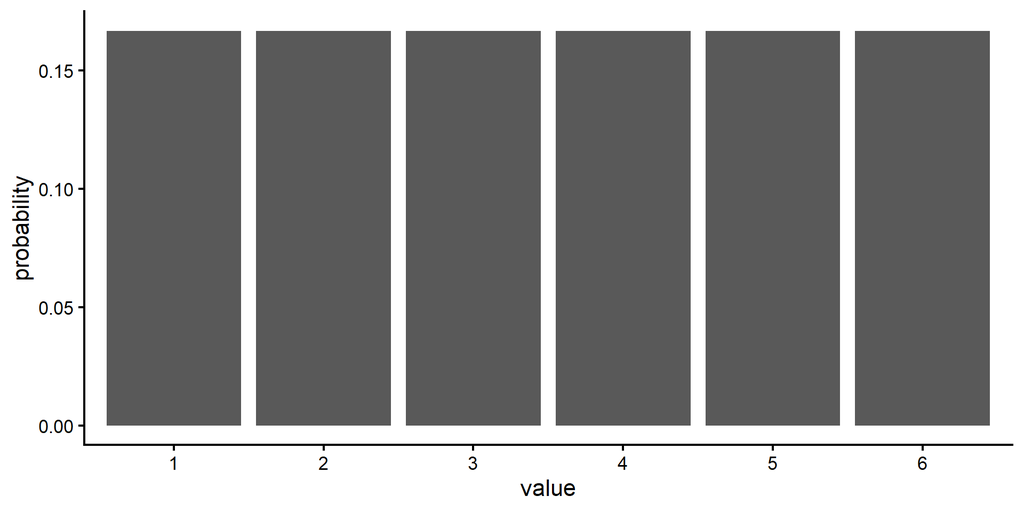

```r
value <- c(1, 2, 3, 4, 5, 6)
probability <- c(1/6, 1/6, 1/6, 1/6, 1/6, 1/6)
rolls <- data.frame(as.factor(value), probability)
ggplot(data = rolls, aes(x = as.factor(value), y = probability)) +
  geom_col() +
  scale_x_discrete(labels = c(1:6)) +
  labs(x = "value")
```

## 2.10 Discrete distributions

- Discrete (categorical) values
- Probability for a value = height of the bar for that value
- Sum of height for all bars = 1
- Uniform, Bernoulli, Binomial, Poisson

## 2.11 Uniform distribution (discrete)

- All possible values are equally likely (uniform probability)
  - Die roll, coin flip
- Notation: $X \sim U\{a,b\}$
- $E(X) = \frac{a+b}{2}$
- $Var(X) = \frac{(b - a + 1)^2 - 1}{12}$

## 2.12 Uniform: 6 sided die

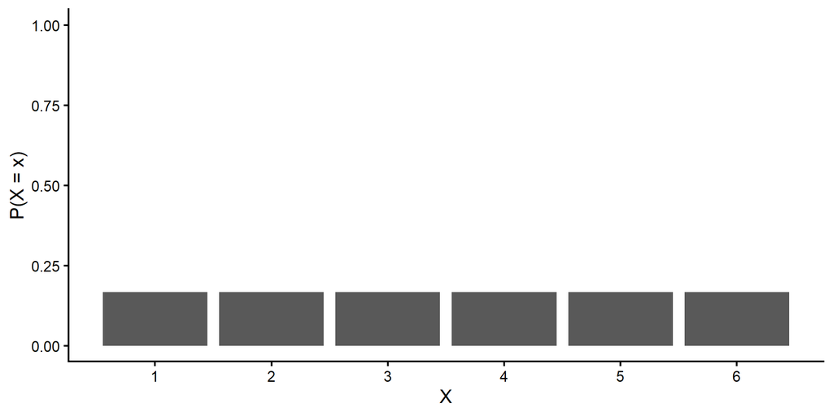

```r
unid_dat <- data.frame(x = 1:6, y = 1/6)

ggplot(data = unid_dat, aes(x = x, y = y)) +
  geom_col() +
  scale_x_continuous(breaks = 1:6) +
  ylim(0,1) +
  labs(x = "X", y = "P(X = x)")
```

- $X \sim U\{1,6\}$
- $E(X) = 3.5$
- $Var(X) = 2.916667$

## 2.13 Bernoulli distribution

- Single trials, each with two possible values (0 = failure, 1 = success)
  - Alive or dead, pass or fail
- Notation: $X \sim B(p)$, where $p$ is the probability of success
- Distribution: $P(X = x) = p^x (1 - p)^{1 -x}$
- $E(X) = p$
- $Var(X) = p(1-p)$

## 2.14 Bernoulli: $p$ = 0.3

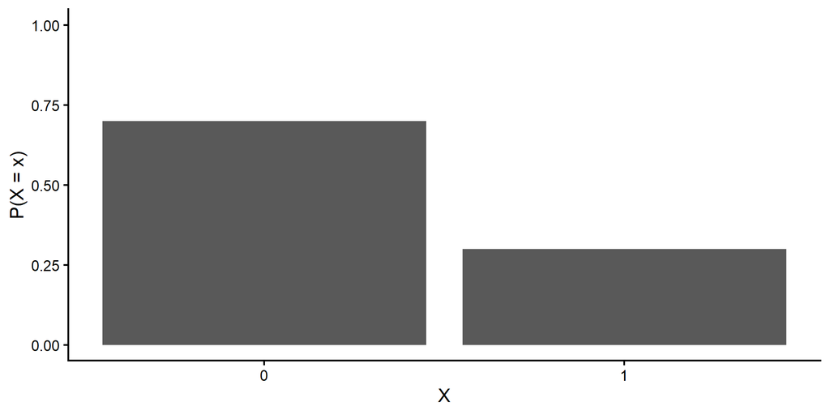

```r
bern_dat <- data.frame(x = 0:1, y = dbinom(0:1, 1, 0.3))
ggplot(data = bern_dat, aes(x = x, y = y)) +
  geom_col() +
  scale_x_continuous(breaks = 0:1) +
  ylim(0,1) +
  labs(x = "X", y = "P(X = x)")
```

- $X \sim B(0.3)$
- $E(X) = 0.3$
- $Var(X) = 0.21$

## 2.15 Binomial distribution

- The sum of $m$ Bernoulli trials (each of which is 0/1)
  - Deaths in a group, passes in a class, voting (yes/no)
- Notation: $X \sim Bin(m, p)$
- Distribution: $P(X = x) = {m \choose x} p^x (1 - p)^{m -x}$
  - ${m \choose x}$ is “$m$ choose $x$”
- $E(X) = mp$
- $Var(X) = mp(1-p)$

## 2.16 Binomial: $m$ = 15, $p$ = 0.5

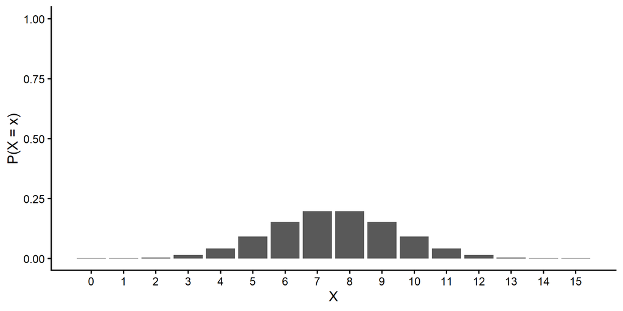

```r
binom_dat <- data.frame(x = 0:15, y = dbinom(0:15, 15, 0.5))
ggplot(data = binom_dat, aes(x = x, y = y)) +
  geom_col() +
  scale_x_continuous(breaks = 0:15) +
  ylim(0,1) +
  labs(x = "X", y = "P(X = x)")
```

- $X \sim Binom(15, 0.5)$
- $E(X) = 7.5$
- $Var(X) = 3.75$

## 2.17 Binomial: $m$ = 25, $p$ = 0.1

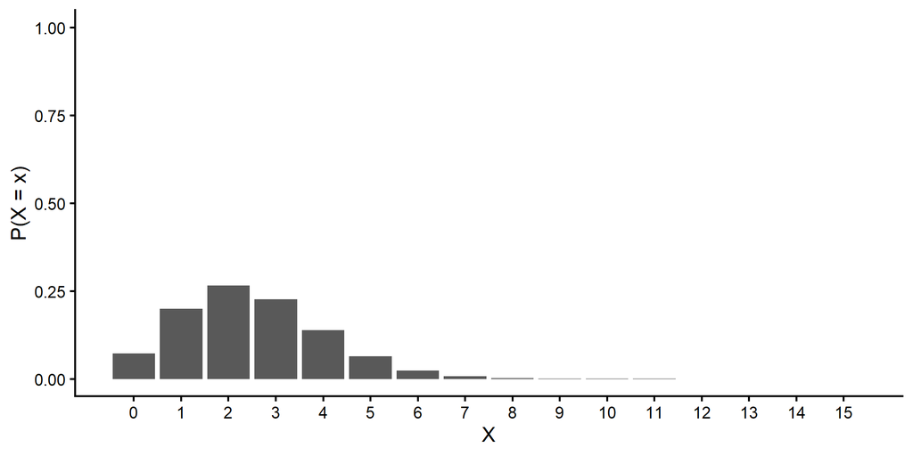

```r
binom_dat <- data.frame(x = 0:15, y = dbinom(0:15, 25, 0.1))
ggplot(data = binom_dat, aes(x = x, y = y)) +
  geom_col() +
  scale_x_continuous(breaks = 0:15) +
  ylim(0,1) +
  labs(x = "X", y = "P(X = x)")
```

- $X \sim Binom(25, 0.1)$
- $E(X) = 2.5$
- $Var(X) = 2.25$

## 2.18 Poisson distribution

- Distribution of *counts* in a fixed period of time
  - Gene expression, earthquakes, days per month in pain
- Notation: $X \sim Pois(\lambda)$, where $\lambda$ is the mean and variance
- Distribution: $P(X = x) = \frac{\lambda^x e^{-\lambda}}{x!}$
- $E(X) = \lambda$
- $Var(X) = \lambda$
- Negative binomial distribution relaxes the mean-variance equality

## 2.19 Poisson: $\lambda$ = 2.5

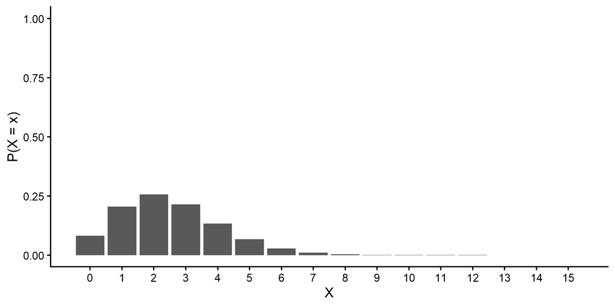

```r
pois_dat <- data.frame(x = 0:15, y = dpois(0:15, 2.5))
ggplot(data = pois_dat, aes(x = x, y = y)) +
  geom_col() +
  scale_x_continuous(breaks = 0:15) +
  ylim(0,1) +
  labs(x = "X", y = "P(X = x)")
```

- $X \sim Pois(2.5)$
- $E(X) = \lambda = 2.5$
- $Var(X) = \lambda = 2.5$

## 2.20 Poisson: $\lambda$ = 5

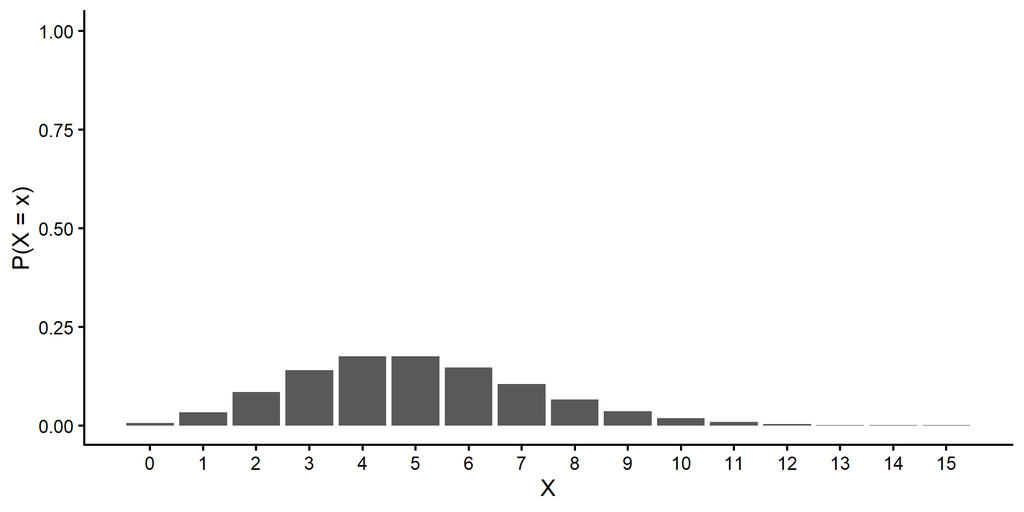

```r
pois_dat <- data.frame(x = 0:15, y = dpois(0:15, 5))
ggplot(data = pois_dat, aes(x = x, y = y)) +
  geom_col() +
  scale_x_continuous(breaks = 0:15) +
  ylim(0,1) +
  labs(x = "X", y = "P(X = x)")
```

- $X \sim Pois(5)$
- $E(X) = \lambda = 5$
- $Var(X) = \lambda = 5$

## 2.21 Continuous distributions

- Continuous (numeric) values
- Height of the line for a value **is not** probability for that value
  - Area under the curve *between* two values = probability *between* those values
- Area under the *entire* curve = 1
- Uniform, Normal (Gaussian), $t$
  - $F$, Chi-square ($\chi^2$)

## 2.22 Uniform distribution (continuous)

- All possible values are equally likely (uniform probability)
  - Wait times
- Notation: $X \sim U(a,b)$
- Distribution: $f(x) = \frac{1}{b-a}$ for $a \le x \le b$
  - $f(x) = 0$ for $x < a$ or $x > b$
- $E(X) = \frac{a+b}{2}$
- $Var(X) = \frac{(b - a)^2}{12}$

## 2.23 Uniform: between 0 and 5

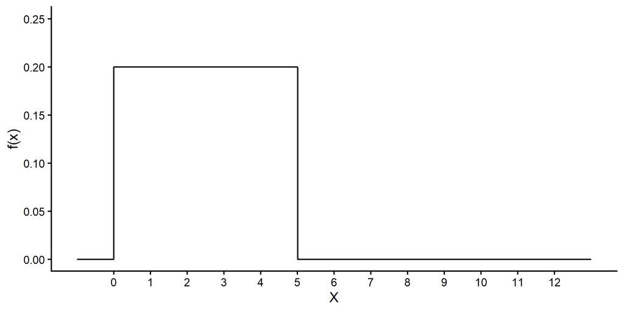

```r
x <- seq(-1, 13, by = 0.01)
y <- dunif(x, 0, 5)
uni_dat <- data.frame(x, y)
ggplot(data = uni_dat, aes(x = x, y = y)) +
  geom_line() +
  scale_x_continuous(limits = c(-1, 13), breaks = 0:12) +
  ylim(0,.25) +
  labs(x = "X", y = "f(x)")
```

- $X \sim U(0,5)$
- $E(X) = 2.5$
- $Var(X) = 2.08$

## 2.24 Uniform: between 3 and 12

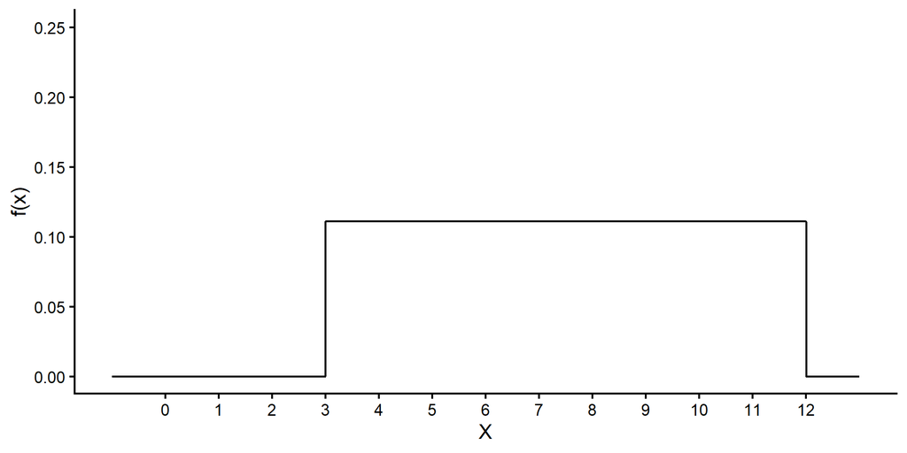

```r
uni_dat <- data.frame(x = seq(-1, 13, by = 0.01), y = dunif(x, 3, 12))
ggplot(data = uni_dat, aes(x = x, y = y)) +
  geom_line() +
  scale_x_continuous(limits = c(-1, 13), breaks = 0:12) +
  ylim(0,.25) +
  labs(x = "X", y = "f(x)")
```

- $X \sim U(3,12)$
- $E(X) = 7.5$
- $Var(X) = 6.75$

## 2.25 Normal distribution

- Gaussian, bell-shaped curve
  - Height, random error, birth weight, SAT scores, statistical tests
- Notation: $X \sim \mathcal{N}(\mu, \sigma^2)$
- Distribution: $f(x) = \frac{1}{\sigma\sqrt{2\pi}} e^{-\frac{1}{2}\left(\frac{x - \mu}{\sigma}\right)}$
- $E(X) = \mu$
- $Var(X) = \sigma^2$
- Modifications: skew-normal, log-normal

## 2.26 Normal: $\mu$ = 0, $\sigma^2$ = 1

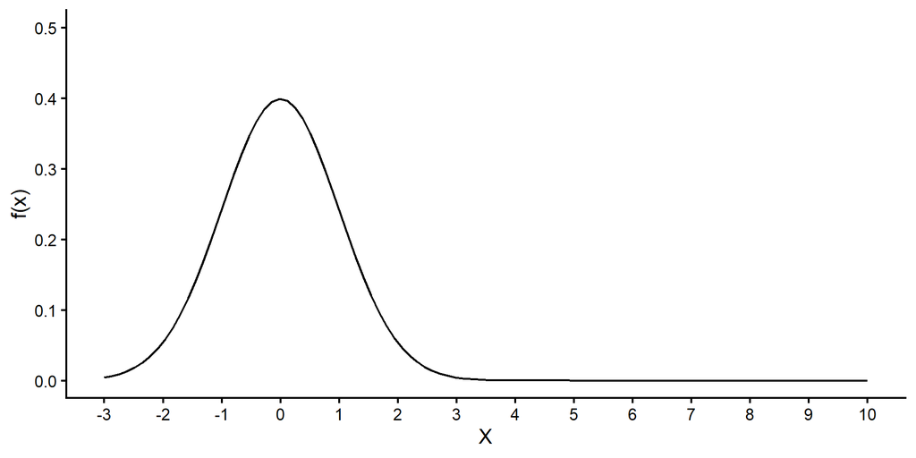

```r
ggplot(data.frame(x = c(-3, 10)), aes(x)) +
  stat_function(fun = dnorm, args = list(mean = 0, sd = 1), geom = "line") +
  ylim(0,.5) +
  scale_x_continuous(breaks = -3:10) +
  labs(x = "X", y = "f(x)")
```

- $X \sim \mathcal{N}(0, 1)$
- $E(X) = \mu = 0$
- $Var(X) = \sigma^2 = 1$

## 2.27 Normal: $\mu$ = 5, $\sigma^2$ = 2

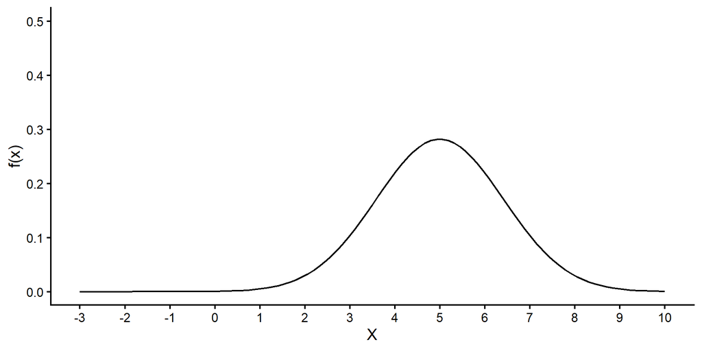

```r
ggplot(data.frame(x = c(-3, 10)), aes(x)) +
  stat_function(fun = dnorm, args = list(mean = 5, sd = sqrt(2)), geom = "line") +
  ylim(0,.5) +
  scale_x_continuous(breaks = -3:10) +
  labs(x = "X", y = "f(x)")
```

- $X \sim \mathcal{N}(5, 2)$
- $E(X) = \mu = 5$
- $Var(X) = \sigma^2 = 2$

## 2.28 (Student’s) $t$ distribution

- **Sampling distribution** for many statistical tests
  - Approximation to normal distribution in small samples
  - Closer as *degrees of freedom* increase
- Notation: $X \sim t(df)$ or $X \sim t(df, ncp)$ or $X \sim t(\mu, \sigma^2, \nu)$
- Distribution: See [here](https://en.wikipedia.org/wiki/Student%27s_t-distribution#Definition) if you’re interested
- $E(X) = 0$ (when $ncp$ = 0)
- $Var(X) = \frac{df}{df-2}$ (when $ncp$ = 0)

## 2.29 $t$: $df$ = 10

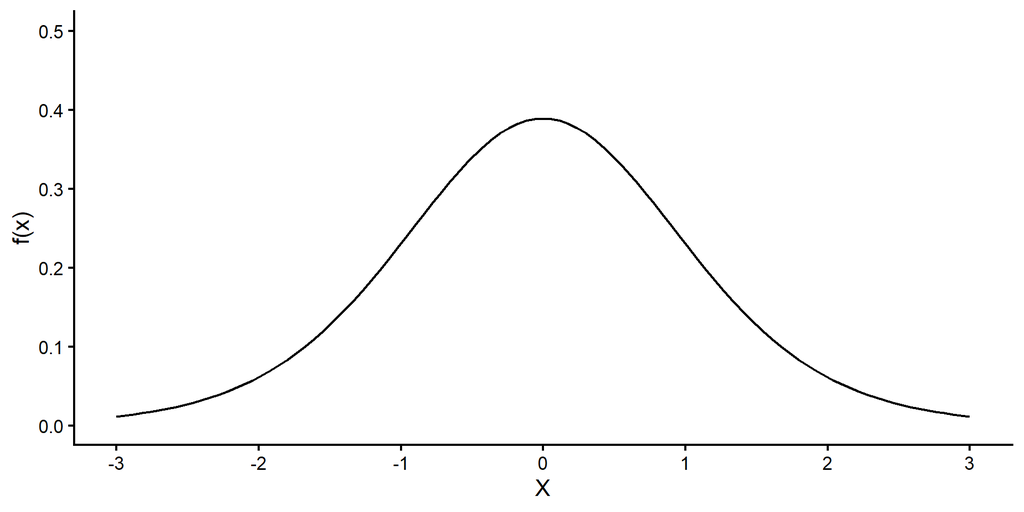

```r
ggplot(data.frame(x = c(-3, 3)), aes(x)) +
  stat_function(fun = dt, args = list(df = 10, ncp = 0), geom = "line") +
  ylim(0,.5) +
  scale_x_continuous(breaks = -3:3) +
  labs(x = "X", y = "f(x)")
```

- $X \sim t(10)$
- $E(X) = 0$
- $Var(X) = 1.25$

## 2.30 $t$: $df$ = 150

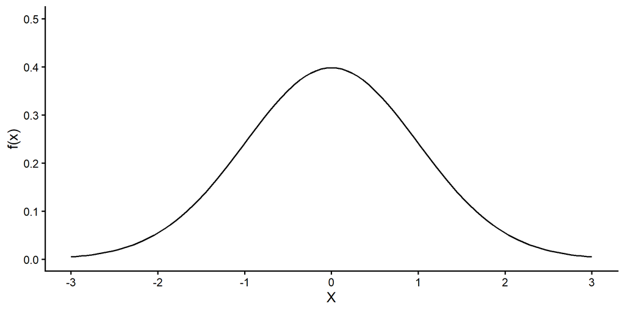

```r
ggplot(data.frame(x = c(-3, 3)), aes(x)) +
  stat_function(fun = dt, args = list(df = 150, ncp = 0), geom = "line") +
  ylim(0,.5) +
  scale_x_continuous(breaks = -3:3) +
  labs(x = "X", y = "f(x)")
```

- $X \sim t(150)$
- $E(X) = 0$
- $Var(X) = 1.0135$

## 2.31 $\mathcal{N}(0, 1)$ (red) vs $t(10)$ (blue)

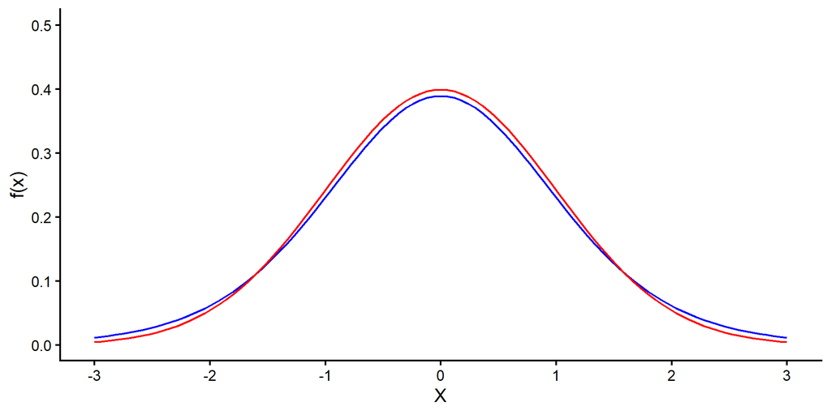

```r
ggplot(data.frame(x = c(-3, 3)), aes(x)) +
  stat_function(fun = dt, args = list(df = 10, ncp = 0), geom = "line", color = "blue", linewidth = 0.75) +
  stat_function(fun = dnorm, args = list(mean = 0, sd = 1), geom = "line", color = "red", linewidth = 0.75) +
  ylim(0,.5) +
  scale_x_continuous(breaks = -3:3) +
  labs(x = "X", y = "f(x)")
```

## 2.32 Summary: Probability distributions

- **Probability** is a way to *quantify uncertainty*
- **Probability distributions** summarize probabilities across all possible values of a random variable
- Variety of discrete and continuous **probability distributions**
  - Some for actual variables, some for statistical tests

# 3 Populations and samples

## 3.1 How does a study work?

```
flowchart LR
  A(Population) --> B{Sampling}
  B{Sampling} --> D[Sample]
```

- Sample from a population

```
flowchart RL
  C{Inference} --> A(Population)
  D[Sample] --> C{Inference}
```

- Make inference from sample back to population

## 3.2 How does a study work?

Step 1. Identify a **population** that you’re interested in

- All units (people, animals, cells) you’re interested in
- This can be very broad
  - All adults in the United States
- Or very specific
  - All *adults* living in *Southern California* who are *> 65 years old* who have had a *heart attack* in *2015*

## 3.3 How does a study work?

Step 2. **Sample** from the population

- Select a *subset* of individuals from the population
  - Do your study on the **sample**
    - Randomize to groups
    - Estimate means
    - Statistical tests

## 3.4 We don’t care about the sample

- The sole purpose of the sample is to let us make *inferences* about the **population**
- Any **individual sample** doesn’t matter
  - Any individual **in the sample** doesn’t matter

## 3.5 The problem with samples

- **They’re not the population** that you’re actually interested in
  - They are not *fully* representative of the population
  - Do not reflect the full *variability* of the population
  - May be *biased* (intentionally or not)
- **Different samples** are also different from **one another**

## 3.6 Uncertainty in sampling

- Create a (normally distributed) population of 1 million values with a mean of 0 and standard deviation of 1
  - $pop \sim \mathcal{N}(0,1)$

```r
pop <- rnorm(1000000, 0, 1)
mean(pop)
```

```
[1] 0.0000667581
```

```r
sd(pop)
```

```
[1] 1.001029
```

## 3.7 Sample 1

- Draw a sample from the population of size $n$ = 100

```r
sample1 <- sample(pop, 100)
mean(sample1)
```

```
[1] 0.06610631
```

```r
sd(sample1)
```

```
[1] 0.968169
```

## 3.8 Sample 2

- Draw another sample from the population of size $n$ = 100

```r
sample2 <- sample(pop, 100)
mean(sample2)
```

```
[1] -0.1525419
```

```r
sd(sample2)
```

```
[1] 0.9083531
```

## 3.9 Sample 3

- Draw another sample from the population of size $n$ = 100

```r
sample3 <- sample(pop, 100)
mean(sample3)
```

```
[1] 0.08553226
```

```r
sd(sample3)
```

```
[1] 0.9714634
```

## 3.10 Sample 4

- Draw another sample from the population of size $n$ = 100

```r
sample4 <- sample(pop, 100)
mean(sample4)
```

```
[1] -0.01909962
```

```r
sd(sample4)
```

```
[1] 0.8953612
```

## 3.11 Sample 5

- Draw another sample from the population of size $n$ = 100

```r
sample5 <- sample(pop, 100)
mean(sample5)
```

```
[1] 0.1106358
```

```r
sd(sample5)
```

```
[1] 0.8906352
```

## 3.12 Sampling variability

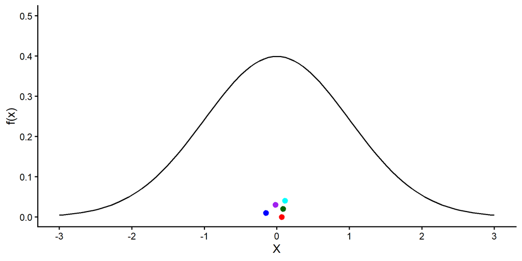

```r
ggplot(data.frame(x = c(-3, 3)), aes(x)) +
  stat_function(fun = dnorm, args = list(mean = 0, sd = 1), geom = "line") +
  ylim(0,.5) +
  scale_x_continuous(breaks = -3:3) +
  labs(x = "X", y = "f(x)") +
  annotate("pointrange", x = mean(sample1), y = 0, ymin = 0, ymax = 0,
  colour = "red", size = .5, linewidth = 1) +
  annotate("pointrange", x = mean(sample2), y = 0.01, ymin = 0.01, ymax = 0.01,
  colour = "blue", size = .5, linewidth = 1) +
  annotate("pointrange", x = mean(sample3), y = 0.02, ymin = 0.02, ymax = 0.02,
  colour = "darkgreen", size = .5, linewidth = 1) +
  annotate("pointrange", x = mean(sample4), y = 0.03, ymin = 0.03, ymax = 0.03,
  colour = "purple", size = .5, linewidth = 1) +
  annotate("pointrange", x = mean(sample5), y = 0.04, ymin = 0.04, ymax = 0.04,
  colour = "cyan", size = .5, linewidth = 1)
```

## 3.13 Sampling variability

- Each **sample mean** is different from the other **sample means**
- Each **sample SD** is different from the other **sample SDs**
- Each **sample mean** is different from the **population mean**
- Each **sample SD** is different from the **population SD**
- How can we deal with this?
  - **Characterize** and *quantify* this variability across samples

# 4 Sampling distribution

## 4.1 Sampling distribution

- **Probability distribution**
- **Quantifies** the *uncertainty* in sampling from a population
  - Sample isn’t representative of the whole population
  - Sampling variability in the test statistic
  - Across all samples from this population, how variable can we expect the test statistic to be?

## 4.2 Sampling distribution

- Sampling distribution depends on
  - Population distribution (somewhat)
  - Sample size
  - Test statistic (e.g., mean, regression coefficient)

## 4.3 Sampling distribution

- Sampling distribution is a **probability distribution**
  - Distribution of a **statistic** (often the *mean*, but can be any statistic, like *regression coefficient*)
    - (**Not** distribution of the observations)
  - Under **repeated sampling** (or all possible samples) from the population
  - With the **same sample size ($n$)**

## 4.4 How do we get sampling distributions?

- **Mathematically derived**
  - Common distributions, like Normal, Bernoulli, etc.
  - Common test statistics like mean, regression coefficient
- **Computationally derived**
  - Monte Carlo simulations, bootstrapping
  - Literally, repeatedly sample from the population (or pseudo population), save the test statistic from each sample, make a distribution (i.e., histogram) of those values

## 4.5 Sampling distribution

- **Normally distributed population**: $\mathcal{N}(0,1)$
- Sampling distribution of the **mean**
- Different **sample sizes**
- This situation can use either method
  - Mathematically derived: $\bar{X} \sim \mathcal{N}(\mu,\frac{\sigma^2}{n})$
  - Simulation based: Literally sample (repeatedly) from population

## 4.6 Sampling dist (math): $n$ = 10, 50, 100

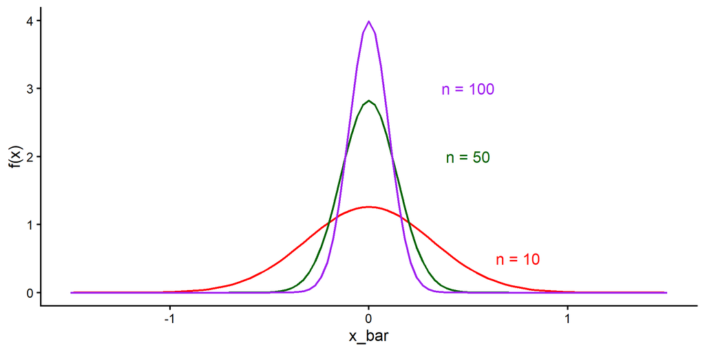

```r
ggplot(data.frame(x = c(-1.5, 1.5)), aes(x)) +
  #stat_function(fun = dnorm, args = list(mean = 0, sd = 1), geom = "line") +
  stat_function(fun = dnorm, args = list(mean = 0, sd = 1/sqrt(10)), geom = "line", color = "red", size = 1) +
  stat_function(fun = dnorm, args = list(mean = 0, sd = 1/sqrt(50)), geom = "line", color = "darkgreen", size = 1) +
  stat_function(fun = dnorm, args = list(mean = 0, sd = 1/sqrt(100)), geom = "line", color = "purple", size = 1) +
  #ylim(0,1) +
  annotate("text", x = 0.75, y = 0.5, label = "n = 10", color = "red") +
  annotate("text", x = 0.5, y = 2, label = "n = 50", color = "darkgreen") +
  annotate("text", x = 0.5, y = 3, label = "n = 100", color = "purple") +
  scale_x_continuous(breaks = -2:2) +
  labs(x = "x_bar", y = "f(x)")
```

## 4.7 Sampling dist (sim): $n$ = 10

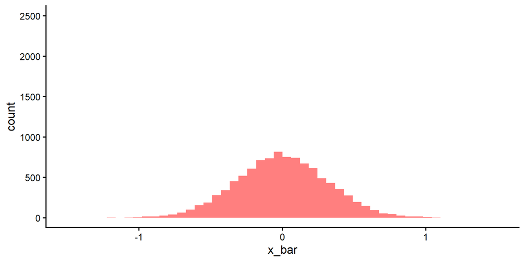

```r
library(infer)
means10 <- data.frame(pop) %>%
  rep_sample_n(size = 10, reps = 10000, replace = TRUE) %>%
  summarise(x_bar = mean(pop))
means50 <- data.frame(pop) %>%
  rep_sample_n(size = 50, reps = 10000, replace = TRUE) %>%
  summarise(x_bar = mean(pop))
means100 <- data.frame(pop) %>%
  rep_sample_n(size = 100, reps = 10000, replace = TRUE) %>%
  summarise(x_bar = mean(pop))

ggplot(data = means10, aes(x = x_bar)) +
  geom_histogram(bins = 50, alpha = 0.5, fill = "red") +
  xlim(-1.5,1.5) +
  ylim(0, 2500)
```

## 4.8 Sampling dist (sim): $n$ = 50

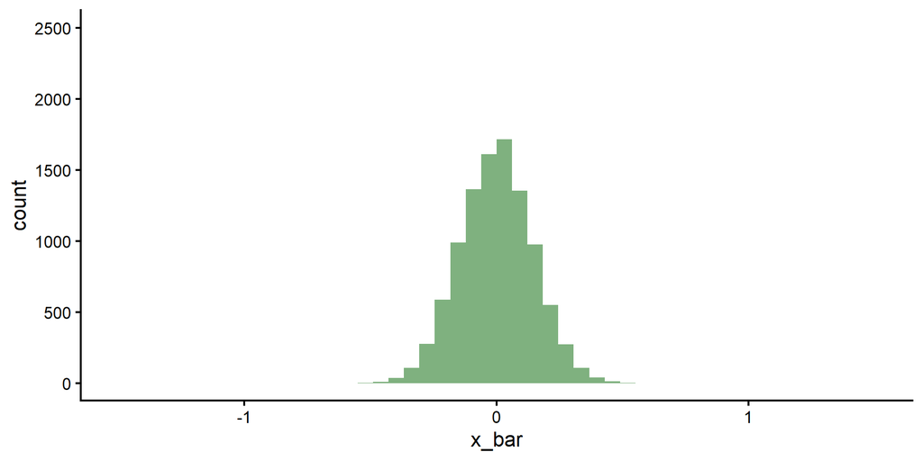

```r
ggplot(data = means50, aes(x = x_bar)) +
  geom_histogram(bins = 50, alpha = 0.5, fill = "darkgreen") +
  xlim(-1.5,1.5) +
  ylim(0, 2500)
```

## 4.9 Sampling dist (sim): $n$ = 100

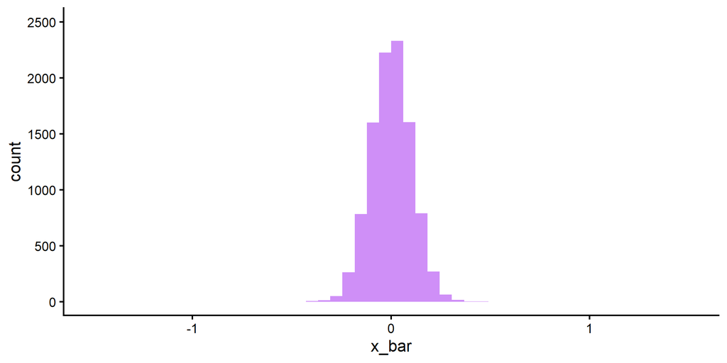

```r
ggplot(data = means100, aes(x = x_bar)) +
  geom_histogram(bins = 50, alpha = 0.5, fill = "purple") +
  xlim(-1.5,1.5) +
  ylim(0, 2500)
```

## 4.10 Why do we care about this?

- Sampling distribution gives the **standard error**
  - Standard deviation of the sampling distribution
  - Tells us about sampling variability in **that test statistic**
  - Across all samples from this population, how variable can we expect the test statistic to be?
    - **Context**
    - Used in significance testing, confidence intervals

# 5 In-class activities

## 5.1 In-class activities

- Explore some sampling distributions using simulation
  - Different *population* distributions
    - Normal, Bernoulli, binomial, Poisson
  - *Sample* 10000 times from each population
    - With different *sample sizes*: $n = 10, 50, 100$
  - Calculate sample mean ($\bar{X}$) for each sample
    - Examine *sampling distributions of means*